# HW5) Data Wrangling

Stat 133, Fall 2024

Author

Wenyi Shi

```r
# packages
library(tidyverse)  # for data science
library(lubridate)  # for working with dates
library(tidytext)   # contains function reorder_within()
```

**General Instructions**

- Write your code and content in a `qmd` (quarto markdown) file. You can use the template file `hw5-template.qmd` provided in bCourses.
- Name this file as `hw5-first-last.qmd`, where `first` and `last` are your first and last names (e.g. `hw5-gaston-sanchez.qmd`).
- Make sure the YAML header in your `qmd` files includes `embed-resources: true`
- Submit both your qmd and HTML files to the corresponding assignment submission in bCourses.
- Please note that submitting only one of the files will result in an automatic 10% deduction.
- Also, if you submit the incorrect files you will receive no credit.

# Visualizing Household Expenditures

This HW involves inspecting and visualizing data—using `"tidyverse"` tools—of monthly expenditures of a family from a large city in the East Coast of the United States.

**Important**

Your graphs should be appropriate for sharing with outsiders. That means your graphs should have, at least:

- title
- labels on the axes

This is just a starting point. Consider including a subtitle, adopting your own color scales, taking control of your legends (if any), including annotations (if applicable), playing around with themes, etc.

## Data Description

The actual data table is in the file `expenses.csv` available in bCourses, (see **Files/hws/hw5**) https://bcourses.berkeley.edu/courses/1531596/files/folder/hws/hw5

The CSV file contains 5 variables:

- `concept`: type of expenditure
- `amount`: amount (in dollars)
- `date`: date (mm/dd/yy)
- `category`: expenditure category
- `mode`: payment mode (debit, credit)

The categories in variable `category` can be divided into 2 buckets:

1. **Cost of living** categories:
   - `insurance`
   - `housing`
   - `utilities`
   - `food`
   - `transportation`
   - `healthcare`
2. **Discretionary spending** categories:
   - `recreation`
   - `personal`
   - `gifts`
   - `vacations`

In addition, the associated time-period goes from January 2019 to December 2023.

**Some Comments:**

- Most expenses are organized by month and year, although not necessarily by day. Also, there may be some expenses with the correct date but placed within expenses of another month.

### Importing `expenses.csv` in R

Download a copy of the CSV file, and place it in your computer in the same folder where you have your `qmd` file for this assignment.

Here’s a suggestion for importing the table into a data frame called `expenses`. You can use other approaches to import the data if you want.

```r
expenses = read_csv(
  file = "expenses.csv",
  col_types = list(
    concept = col_character(),
    amount = col_double(),
    date = col_date(format = "%m/%d/%y"),
    category = col_character(),
    mode = col_character()
  ))
```

### Adding Type of Expenses

For convenience purposes, let’s add a column `type` to indicate if a given expense has to do with “cost of living expenses” or with “discretionary” ones.

```r
# for convenience purposes, let's add a column "type" to group
# "cost of living" categories, and "discretionary" categories
cost_living_exps = c(
  'insurance',
  'housing',
  'utilities',
  'food',
  'transportation',
  'healthcare')

discretionary_exps = c(
  'recreation',
  'personal',
  'gifts',
  'vacations'
)

expenses = expenses |>
  mutate(
    type = case_when(
      category %in% cost_living_exps ~ "cost-living",
      category %in% discretionary_exps ~ "discretionary")
  )
```

# 1 Very specific prompts

1. Based on the column `date`, add—i.e. `mutate()`—a column `year` and a column `month` to the table `expenses`. Do this by using the functions `year()` and `month()`—which are part of the package `"lubridate"`. With the updated `expenses`, display its last 10 rows.

```r
# your code
expenses = mutate(expenses, year = year(date), month = month(date))
expenses
```

```
# A tibble: 2,021 × 8
   concept         amount date       category  mode   type           year month
   <chr>            <dbl> <date>     <chr>     <chr>  <chr>         <dbl> <dbl>
 1 rent           1619.   2019-01-03 housing   debit  cost-living    2019     1
 2 internet         67.0  2019-01-07 utilities debit  cost-living    2019     1
 3 home insurance   16.5  2019-01-09 insurance debit  cost-living    2019     1
 4 cell phone       58.4  2019-01-14 utilities credit cost-living    2019     1
 5 life insurance   86.0  2019-01-07 insurance credit cost-living    2019     1
 6 energy            4.92 2019-01-10 utilities debit  cost-living    2019     1
 7 car insurance   384.   2019-01-09 insurance credit cost-living    2019     1
 8 retailer         39.7  2019-01-03 gifts     credit discretionary  2019     1
 9 retailer         32.7  2019-01-16 gifts     debit  discretionary  2019     1
10 groceries       104.   2019-01-21 food      credit cost-living    2019     1
# ℹ 2,011 more rows
```

2. Write `dplyr` commands that let you identify which type of `category` is the most frequent? In other words, which category has the largest number of transactions? **Hint:** `count()` is your friend.

```r
# your code
count(expenses, category)
```

```
# A tibble: 10 × 2
   category           n
   <chr>          <int>
 1 food             493
 2 gifts             91
 3 healthcare        83
 4 housing          161
 5 insurance        187
 6 personal         275
 7 recreation       277
 8 transportation   163
 9 utilities        181
10 vacations        110
```

3. Use `dplyr` commands to display the top-10 largest expenses of all time **excluding rent expenses**. This table should contain columns `concept`, `amount`, and `date` (in that order). Content should be arranged in decreasing order by `amount`. Display the obtained table.

```r
# your code
filter(expenses, concept != "rent") |>
  select(concept, amount, date) |>
  arrange(desc(amount)) |>
  slice(1:10)
```

```
# A tibble: 10 × 3
   concept       amount date
   <chr>          <dbl> <date>
 1 retailer       6857  2020-11-14
 2 cash transfer  2050  2023-03-03
 3 retailer       1827. 2021-02-04
 4 retailer       1684  2021-12-13
 5 trip expenses  1487  2020-10-18
 6 retailer       1461  2021-12-21
 7 trip expenses  1380. 2023-01-21
 8 entertainment  1323. 2023-05-08
 9 trip expenses  1277  2020-06-30
10 retailer       1204. 2021-02-04
```

4. Suppose that one of your classmates wrote the following commands to obtain a table containing the smallest expense per month-year. Notice the `group_by()` command in which the function `floor_date()` is used to create an auxiliary column `month_year` to indicate the year and month of the minimum expense (please ignore the day value, which plays a dummy role).

```r
# minimum expenses per month-year
monthly_min_expenses = expenses |>
  group_by(month_year = floor_date(date, unit = 'month')) |>
  summarise(min_exp = min(amount), .groups = "drop")

# display first 5 rows
monthly_min_expenses |>
  slice_head(n = 5)
```

```
# A tibble: 5 × 2
  month_year min_exp
  <date>       <dbl>
1 2019-01-01    4.92
2 2019-02-01    1
3 2019-03-01    0.8
4 2019-04-01    1.25
5 2019-05-01    4.25
```

Use the sample command provided above to obtain a table `monthly_expenses` containing the **total amount** spent in each month, per year. To clarify: each row corresponds to the total amount spent in a given month-year. Display the last 10 rows of your table.

```r
# your code
monthly_expenses = expenses |>
  group_by(month_year = floor_date(date, unit = 'month')) |>
  summarise(total_amount = sum(amount), .groups = "drop")

# display first 5 rows
monthly_expenses |>
  slice_tail(n = 10)
```

```
# A tibble: 10 × 2
   month_year total_amount
   <date>            <dbl>
 1 2023-03-01        8965.
 2 2023-04-01        5671.
 3 2023-05-01        6365.
 4 2023-06-01        3835.
 5 2023-07-01        7353.
 6 2023-08-01        6205.
 7 2023-09-01        5488.
 8 2023-10-01        5541.
 9 2023-11-01        5609.
10 2023-12-01        6565.
```

5. Refer to the table `monthly_expenses` obtained in the previous part. Use `ggplot2` commands to visualize the total monthly expenses over time.

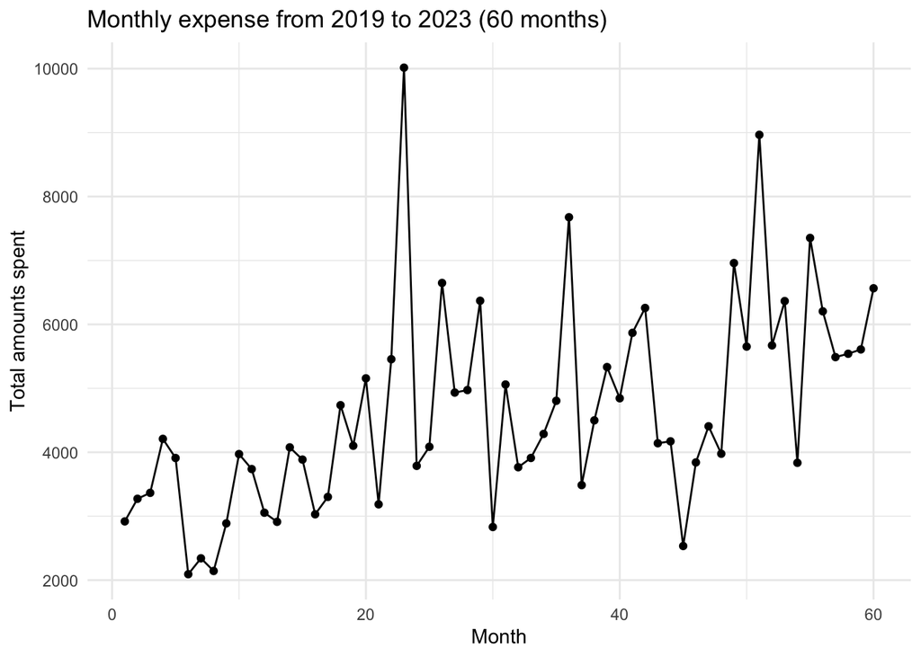

```r
# your code
ggplot(data = monthly_expenses, aes(x = 1:nrow(monthly_expenses), y = total_amount)) +
  geom_point() +
  geom_line() +
  labs(title = "Monthly expense from 2019 to 2023 (60 months)",
       x = "Month",
       y = "Total amounts spent") +
  theme_minimal()
```

6. Refer to the `expenses` table. Based on columns `month` and `amount`, use `dplyr` commands to obtain a single table containing the monthly first-quartile amount, the monthly median amount, and the monthly third-quartile amount. To clarify: this table should have only 12 rows (one row per month). *Hint*: the `quantile()` function lets you compute quartiles.

```r
# your code
summarise(
  group_by(expenses, month),
  first_quartile = quantile(amount, 0.25),
  median = median(amount),
  third_quartile = quantile(amount, 0.75),
)
```

```
# A tibble: 12 × 4
   month first_quartile median third_quartile
   <dbl>          <dbl>  <dbl>          <dbl>
 1     1           20     42.5           95
 2     2           18.0   45.0           95
 3     3           17.6   48.3           95
 4     4           16.8   40             92.3
 5     5           19.8   45.0           85.2
 6     6           19.3   45.9           94.5
 7     7           19.4   48.0           95
 8     8           20.2   54.2           95
 9     9           20.2   45.7           95
10    10           17.7   42.5          103.
11    11           20     48.3           95
12    12           20.5   55.7          100.
```

7. Refer to the `expenses` table. Use `dplyr` commands to obtain a single table containing the *average amount* and the *median amount* by `category`; arranging values by *average amount* (increasingly). Display the obtained table.

```r
# your code
expenses |>
  group_by(category) |>
  summarize(average_amount = mean(amount), median_amount = median(amount)) |>
  arrange(average_amount)
```

```
# A tibble: 10 × 3
   category       average_amount median_amount
   <chr>                   <dbl>         <dbl>
 1 transportation           40.5          20
 2 recreation               45.1          21.4
 3 utilities                64.1          56.3
 4 healthcare               68.0          25.0
 5 food                     72.1          42.0
 6 insurance                79.4          69.8
 7 personal                 86.7          51.6
 8 gifts                   119.           50.5
 9 vacations               285.          126.
10 housing                 781.          193.
```

8. Refer to the `expenses` table. Use `dplyr` and `ggplot2` commands to make a bar-chart to visualize the **total expenses for each category**. The bars should be horizontally oriented, displayed in decreasing order. **Hint**: you may need to google how to `reorder()` bars in a ggplot graphic.

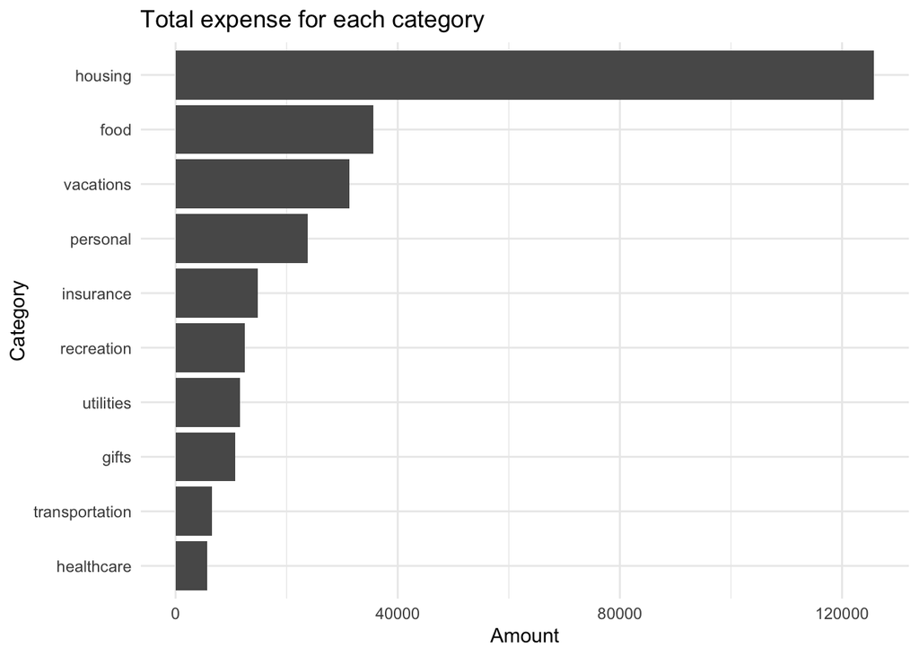

```r
# your code
temp = expenses |>
  group_by(category) |>
  summarize(total_amount = sum(amount))

ggplot(data = temp, aes(x = total_amount, y = reorder(category, total_amount))) +
  geom_bar(stat='identity') +
  labs(title = "Total expense for each category",
       x = "Amount",
       y = "Category") +
  theme_minimal()
```

1. Refer to the `expenses` table. Use `dplyr` commands to obtain a table `vacations_expenses` containing the **total vacations expenses** grouped by `year` and `month`. The resulting table should have three columns (`year`, `month` and `total_amount`). **Hint**: the argument `.groups = "drop"` in function `summarise()` is your friend.

   For displaying purposes, arrange the values decreasingly (by total spent amount), and show only the top-10 total vacations expenses.

```r
# your code
vacations_expenses = expenses |>
  group_by(month_year = floor_date(date, unit = 'month')) |>
  summarise(total_amount = sum(amount), .groups = "drop") |>
  mutate(year = year(month_year), month = month(month_year)) |>
  arrange(desc(total_amount)) |>
  select(year, month, total_amount)

slice_head(vacations_expenses, n = 10)
```

```
# A tibble: 10 × 3
    year month total_amount
   <dbl> <dbl>        <dbl>
 1  2020    11       10016.
 2  2023     3        8965.
 3  2021    12        7676.
 4  2023     7        7353.
 5  2023     1        6960.
 6  2021     2        6649.
 7  2023    12        6565.
 8  2021     5        6370.
 9  2023     5        6365.
10  2022     6        6257.
```

10. Refer to the table `vacations_expenses`. Use `dplyr` and `ggplot2` commands to make a bar-chart to visualize the **total vacations expenses by year**. To clarify, this bar chart should have as many bars as years in the data.

[figure not shown]

```r
# your code
per_year_expense =
  vacations_expenses |>
  group_by(year) |>
  summarise(total_amount_per_year = sum(total_amount))

ggplot(data = per_year_expense, aes(x = year, y =  total_amount_per_year)) +
  geom_bar(stat='identity') +
  labs(title = "Total vacations expenses by year",
       x = "Year",
       y = "Total amount") +
  theme_minimal()
```

# 2 More open-ended questions

Answer the following questions.

**Important**

- All the graphics must include a meaningful title, and also a subtitle.
- Make sure axes are labeled.
- Do not use the default ggplot theme.
- Likewise, include a concise description of what’s going on in each graphic.

## 2.1 Mean Recreation and Personal expenses per month-year

Suppose that one of your classmates wrote the following commands to obtain a table of mean Recreation and mean Personal expenses per month-year.

```r
# mean recreation exps. and mean personal exps. per month-year
personal_recreation_expenses = expenses |>
  filter(category %in% c("recreation", "personal")) |>
  group_by(month_year = floor_date(date, unit = 'month'), category) |>
  summarise(mean = mean(amount), .groups = "drop")

# first 10-rows displayed (for sake of illustration)
personal_recreation_expenses |> slice_head(n = 10)
```

```
# A tibble: 10 × 3
   month_year category     mean
   <date>     <chr>       <dbl>
 1 2019-01-01 personal   115.
 2 2019-01-01 recreation  10.9
 3 2019-02-01 personal    34.7
 4 2019-02-01 recreation  18.1
 5 2019-03-01 personal    32.5
 6 2019-03-01 recreation  10.7
 7 2019-04-01 personal   115.
 8 2019-04-01 recreation   4.25
 9 2019-05-01 personal    50.4
10 2019-05-01 recreation   4.5
```

Help your classmate create a ggplot graphic that allows you to compare timelines of the mean Recreation spent amount and the mean Personal spent amount over time.

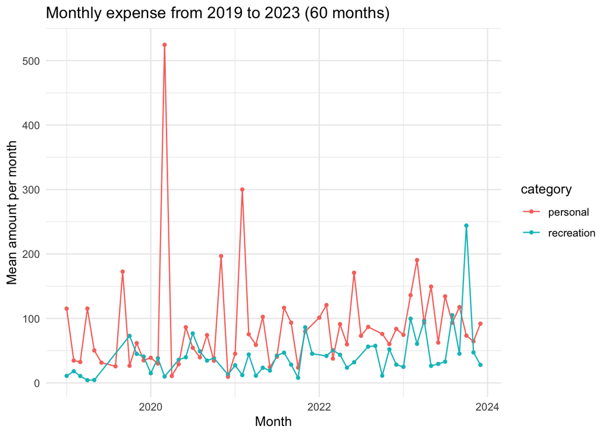

```r
# your code
ggplot(data = personal_recreation_expenses, aes(x = month_year, y = mean)) +
  geom_point(aes(color = category), size = 1) +
  geom_line(aes(color = category)) +
  labs(title = "Monthly expense from 2019 to 2023 (60 months)",
       x = "Month",
       y = "Mean amount per month") +
  theme_minimal()
```

## 2.2 Trimesterly Expenditures Over Time

Refer to the table `expenses`. Create a visual display that lets us see the total trimesterly expenditures over the provided months-years. **Hint**: like in the preceding problem, the following `group_by()` command allows you to obtain a `trimester_year` variable which may be very handy for computing trimesterly expenditures: `group_by(trimester_year = ceiling_date(date, unit = 'season'))`

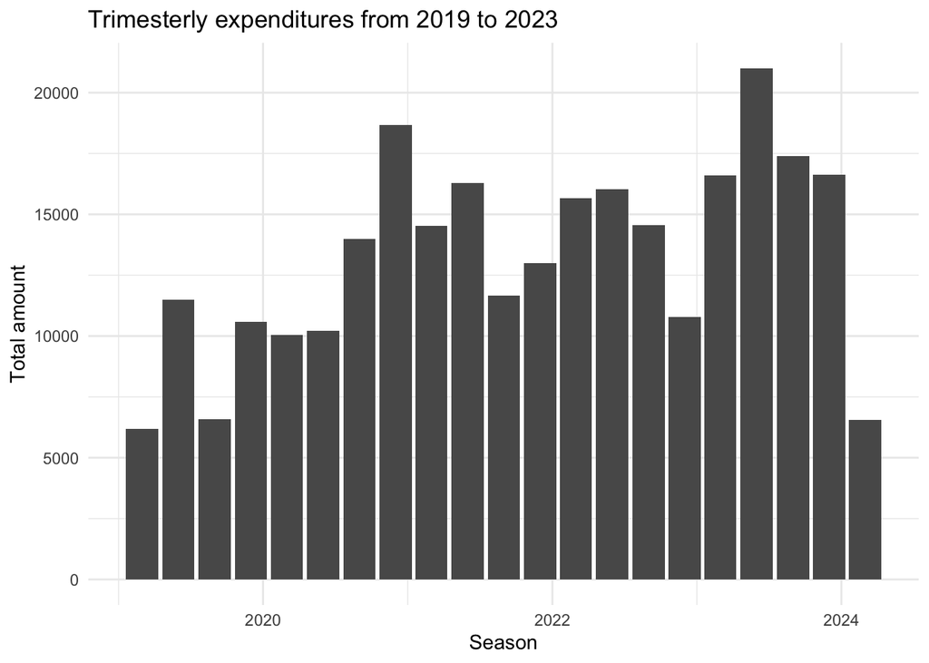

```r
# your code
temp = expenses |>
  group_by(trimester_year = ceiling_date(date, unit = 'season')) |>
  summarise(trimester_year_amount = sum(amount), .groups = "drop")

ggplot(data = temp, aes(x = trimester_year, y = trimester_year_amount)) +
  geom_bar(stat='identity') +
  labs(title = "Trimesterly expenditures from 2019 to 2023",
       x = "Season",
       y = "Total amount") +
  theme_minimal()
```

## 2.3 Cost-of-Living vs Discretionary Spending

Refer to the table `expenses`. Create a plot that lets us compare, over time, the cost-of-living spending versus the discretionary spending.

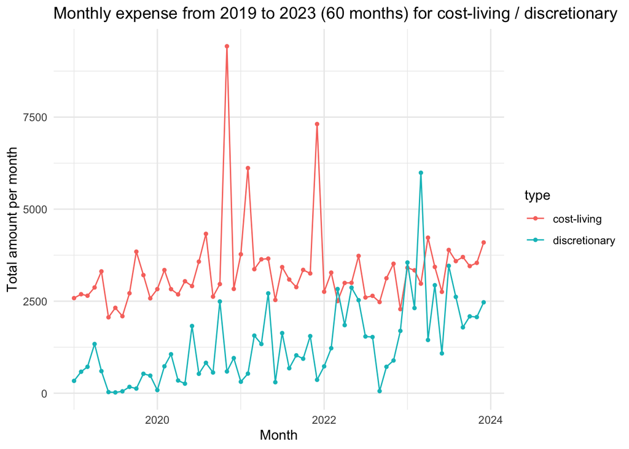

```r
# your code
temp = expenses |>
  group_by(type, month_year = floor_date(date, unit = 'month')) |>
  summarise(total_amount = sum(amount), .groups = "drop")

ggplot(data = temp, aes(x = month_year, y = total_amount, color=type)) +
  geom_point(aes(color = type), size = 1) +
  geom_line(aes(color = type)) +
  labs(title = "Monthly expense from 2019 to 2023 (60 months) for cost-living / discretionary",
       x = "Month",
       y = "Total amount per month") +
  theme_minimal()
```

## 2.4 Top-5 Annual Expenditure Categories

### Example

Refer to the table `expenses`. As an example, suppose that one of the GSIs use `dplyr` commands to obtain a table `top3_concept_expenses` containing the top-3 largest expenditures by `concept` and `year` (a few rows shown below)

```r
top3_concept_expenses = expenses |>
  select(year, concept, amount) |>
  group_by(year, concept) |>
  summarize(max_amount = max(amount), .groups = "drop") |>
  group_by(year) |>
  slice_max(n = 3, order_by = max_amount)
```

```
year  concept        max_amount
2019  rent              1659.95
2019  fitness            575.00
2019  trip expenses      572.54
2020  retailer          6857.00
2020  rent              1699.95
2020  trip expenses     1487.00
2021  retailer          1826.86
2021  rent              1710.95
2021  trip expenses      956.54
```

To visualize this data set, the GSI employed a bar chart produced by the following `ggplot` commands. Notice the use of the `reorder_wihtin()` function—from the package `"tidytext"`—to arrange the bars in decreasing order within each facet.

```r
# sample code
# BTW: this plot needs a title, subtitle, axis labels, and a nicer theme
top3_concept_expenses |>
  ggplot() +
  geom_col(aes(x = reorder_within(concept, max_amount, year),
               y = max_amount,
               fill = concept)) +
  scale_x_reordered() +
  facet_wrap(~ year, scales = "free", strip.position = "top") +
  coord_flip() +
  theme(legend.position = "none")
```

### 2.4.1 Top-5 total expenditures by `category` in each year

Refer to the table `expenses`. Create a visualization to display the top-5 total expenditures by `category` in every year. This involves computing the total amount spent per category in each year, and choosing the top-5 values in each year.

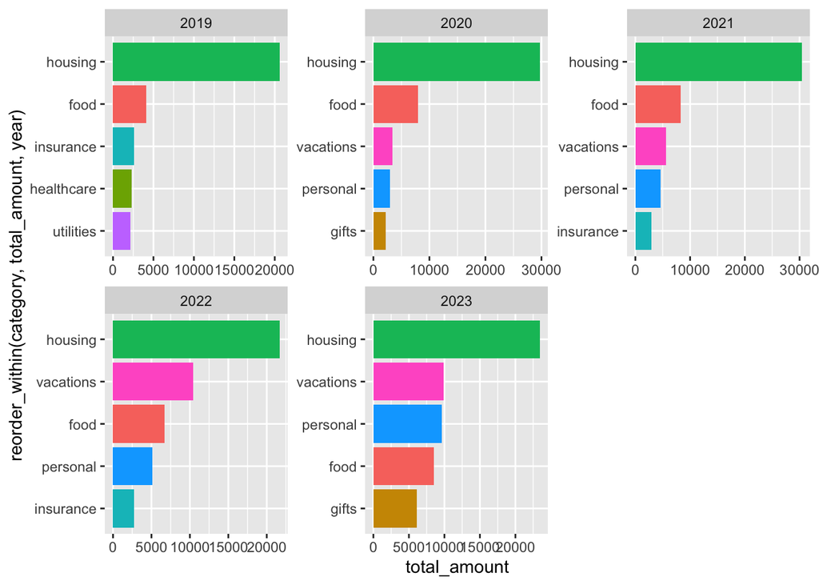

```r
# your code
top5_category_expenses = expenses |>
  select(year, category, amount) |>
  group_by(year, category) |>
  summarize(total_amount = sum(amount), .groups = "drop") |>
  group_by(year) |>
  slice_max(n = 5, order_by = total_amount)

top5_category_expenses |>
  ggplot() +
  geom_col(aes(x = reorder_within(category, total_amount, year),
               y = total_amount,
               fill = category)) +
  scale_x_reordered() +
  facet_wrap(~ year, scales = "free", strip.position = "top") +
  coord_flip() +
  theme(legend.position = "none")
```

## Rubric

- 😞 **None (0 pts)**: No submission; or terribly wrong; or incorrect files.
- 😟 **Deficient (1 pt)**: Displays minimal effort. Fairly incomplete. Code is poorly written and not documented.
- 🙁 **Needs improvement (2 pts)**: Displays some effort. Doesn’t complete all components. Code is poorly written and not documented. Just contains code and output but no descriptions, explanations or interpretations. Possibly a major issue or mistake.
- 😐 **Satisfactory (3 pts)**: Decent effort. Hits all the elements. Possibly a couple of minor mistakes or some non-minor issue. Code is mostly okay, but some data manipulations or graphics could be done in a better way; there is room for better comments, and/or format. Fairly basic plots produced with default settings (i.e. minimal or no customization). Nothing spectacular, either bad or good.
- 🙂 **Good (4 pts)**: Solid effort. Hits all the elements. Possibly a minor mistake. Easy to follow (both the code and the output). Most plots are customized (labels, colors, theme, etc). Takes care of well presented information (e.g. proper use of markdown elements, no spelling issues, well organized).
- 😀 **Excellent (5 pts)**: Finished all components of the assignment correctly. Code is well-documented (both self-documented and with additional comments as necessary). Graphs properly labeled/annotated. Uses non-default settings, highly customizing the graphics to give them an outstanding appearance (i.e. publication quality). Descriptions are clear and easy to follow, either because graphs are labeled clearly or you’ve written additional text to describe how you interpret the output. Spectacular submission, that can be used as an *exemplary solution*.